# R Notebook

# Predict a Player’s All-Star Rank From Traditional Statistics

This notebook utilizes various statistical models to predict a player’s potential to achieve an All-Star rank based on traditional statistics, excluding Wins Above Replacement (WAR).

## Setup Libraries and Data Loading

Load necessary libraries and import the dataset, preparing it for analysis by selecting relevant features and transforming the Top100Status column.

```r
library(dplyr)
library(tidyr)
library(caret)
library(corrplot)

data <- read.csv("dataset/processed_data.csv")
data <- data %>% select(-WinsAboveReplacement)
```

```r
colnames(data)
```

```
 [1] "Rank"               "Triples"            "HomeRuns"           "StolenBases"        "BaseOnBalls"        "Strikeouts"
 [7] "BattingAverage"     "OnBasePercentage"   "SluggingPercentage" "OnBasePlusSlugging" "IntentionalWalks"   "GamesStarted"
[13] "BattingStats"       "DefenseStats"       "Top100Status"
```

```r
print(head(data$Top100Status))
```

```
[1] "No" "No" "No" "No" "No" "No"
```

```r
data$Top100Status <- ifelse(data$Top100Status == "No", 0, 1)
print(head(data$Top100Status))
```

```
[1] 0 0 0 0 0 0
```

## Step 1: Logistic Regression

Prepare the data and fit a logistic regression model to predict the Top100Status from available features.

```r
set.seed(123)
index <- createDataPartition(data$Top100Status, p = 0.8, list = FALSE)
train_data <- data[index,]
test_data <- data[-index,]
```

```r
# Fit logistic regression model
logit_model <- glm(Top100Status ~ ., data = train_data, family = binomial())

# Predictions
predictions <- predict(logit_model, test_data, type = "response")
predicted_class <- ifelse(predictions > 0.5, 1, 0)

# Model evaluation
confusionMatrix(factor(predicted_class), factor(test_data$Top100Status), positive = "1")
```

```
Confusion Matrix and Statistics

          Reference
Prediction    0    1
         0 4372  221
         1   33  113

               Accuracy : 0.9464
                 95% CI : (0.9396, 0.9526)
    No Information Rate : 0.9295
    P-Value [Acc > NIR] : 1.378e-06

                  Kappa : 0.4471

 Mcnemar's Test P-Value : < 2.2e-16

            Sensitivity : 0.33832
            Specificity : 0.99251
         Pos Pred Value : 0.77397
         Neg Pred Value : 0.95188
             Prevalence : 0.07048
         Detection Rate : 0.02384
   Detection Prevalence : 0.03081
      Balanced Accuracy : 0.66542

       'Positive' Class : 1
```

The model’s specificity of 99.25% indicates a high accuracy in correctly identifying players who do not achieve all-star status, reflecting effective discrimination against false positives. However, its sensitivity of 33.83% suggests it is considerably less effective at correctly identifying actual all-stars, as it misses about two-thirds of these cases, highlighting a need for improvement in detecting true positives within the dataset.

## Step 2: L1/L2 Regularization (Logistic Regression with Ridge and Lasso)

Use regularization techniques to enhance the logistic regression model’s performance and avoid overfitting.

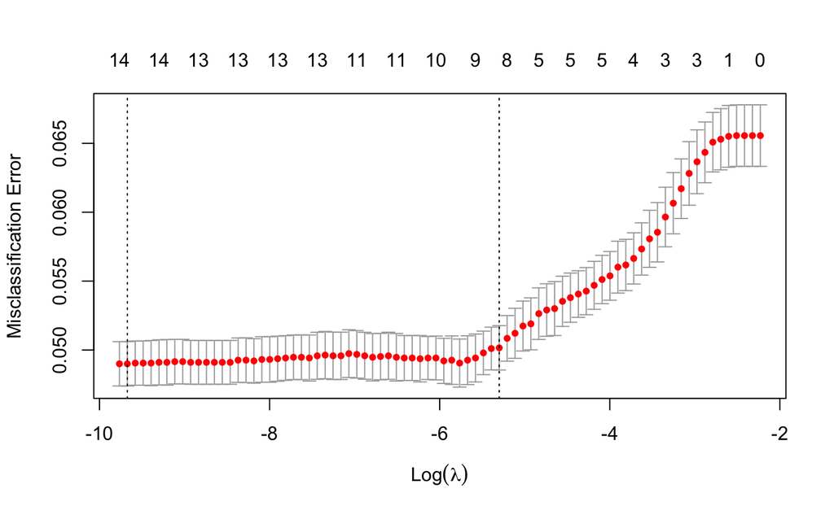

```r
library(glmnet)
x <- model.matrix(Top100Status ~ . - 1, data = train_data)  # -1 to exclude intercept
y <- train_data$Top100Status

lasso_model <- glmnet(x, y, family = "binomial", alpha = 1)
ridge_model <- glmnet(x, y, family = "binomial", alpha = 0)

cv_lasso <- cv.glmnet(x, y, family = "binomial", type.measure = "class", alpha = 1)
cv_ridge <- cv.glmnet(x, y, family = "binomial", type.measure = "class", alpha = 0)

plot(cv_lasso)
```

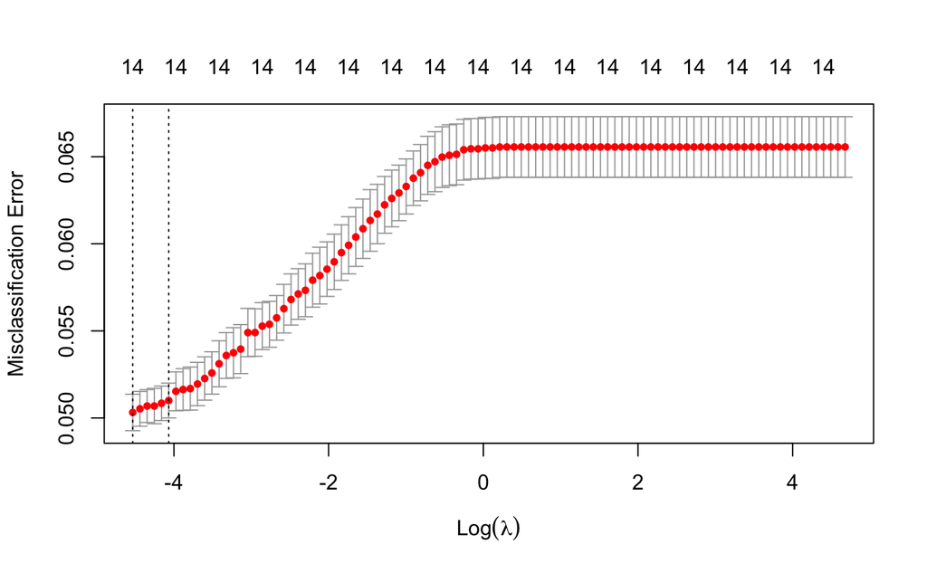

```r
plot(cv_ridge)
```

```r
library(caret)

# Predict using the optimal lambda from cross-validation
lasso_pred_prob <- predict(cv_lasso, newx = model.matrix(Top100Status ~ . - 1, data = test_data), s = "lambda.min", type = "response")
ridge_pred_prob <- predict(cv_ridge, newx = model.matrix(Top100Status ~ . - 1, data = test_data), s = "lambda.min", type = "response")

# Convert probabilities to class predictions based on a threshold (default is 0.5)
lasso_pred_class <- ifelse(lasso_pred_prob > 0.5, 1, 0)
ridge_pred_class <- ifelse(ridge_pred_prob > 0.5, 1, 0)
# Confusion matrix for the Lasso model
lasso_conf_matrix <- confusionMatrix(factor(lasso_pred_class), factor(test_data$Top100Status))
print("Confusion Matrix for Lasso Model:")
```

```
[1] "Confusion Matrix for Lasso Model:"
```

```r
print(lasso_conf_matrix)
```

```
Confusion Matrix and Statistics

          Reference
Prediction    0    1
         0 4373  222
         1   32  112

               Accuracy : 0.9464
                 95% CI : (0.9396, 0.9526)
    No Information Rate : 0.9295
    P-Value [Acc > NIR] : 1.378e-06

                  Kappa : 0.4451

 Mcnemar's Test P-Value : < 2.2e-16

            Sensitivity : 0.9927
            Specificity : 0.3353
         Pos Pred Value : 0.9517
         Neg Pred Value : 0.7778
             Prevalence : 0.9295
         Detection Rate : 0.9228
   Detection Prevalence : 0.9696
      Balanced Accuracy : 0.6640

       'Positive' Class : 0
```

```r
# Confusion matrix for the Ridge model
ridge_conf_matrix <- confusionMatrix(factor(ridge_pred_class), factor(test_data$Top100Status))
print("Confusion Matrix for Ridge Model:")
```

```
[1] "Confusion Matrix for Ridge Model:"
```

```r
print(ridge_conf_matrix)
```

```
Confusion Matrix and Statistics

          Reference
Prediction    0    1
         0 4387  242
         1   18   92

               Accuracy : 0.9451
                 95% CI : (0.9383, 0.9514)
    No Information Rate : 0.9295
    P-Value [Acc > NIR] : 7.821e-06

                  Kappa : 0.3932

 Mcnemar's Test P-Value : < 2.2e-16

            Sensitivity : 0.9959
            Specificity : 0.2754
         Pos Pred Value : 0.9477
         Neg Pred Value : 0.8364
             Prevalence : 0.9295
         Detection Rate : 0.9257
   Detection Prevalence : 0.9768
      Balanced Accuracy : 0.6357

       'Positive' Class : 0
```

Despite various modeling attempts, including logistic regression and regularization techniques, there has been no significant improvement in the specificity of predicting whether a player has a top rank based on statistics that exclude WAR, indicating that the current models are ineffective at accurately identifying players with top rankings from the available data.

## Step 3: Decision Tree

Fit a decision tree model to classify players based on their traditional statistics.

```r
library(rpart)

# Fit decision tree model
tree_model <- rpart(Top100Status ~ ., data = train_data, method = "class")

# Predictions and evaluation
tree_predictions <- predict(tree_model, test_data, type = "class")
confusionMatrix(tree_predictions, factor(test_data$Top100Status))
```

```
Confusion Matrix and Statistics

          Reference
Prediction    0    1
         0 4365  199
         1   40  135

               Accuracy : 0.9496
                 95% CI : (0.9429, 0.9556)
    No Information Rate : 0.9295
    P-Value [Acc > NIR] : 9.441e-09

                  Kappa : 0.5065

 Mcnemar's Test P-Value : < 2.2e-16

            Sensitivity : 0.9909
            Specificity : 0.4042
         Pos Pred Value : 0.9564
         Neg Pred Value : 0.7714
             Prevalence : 0.9295
         Detection Rate : 0.9211
   Detection Prevalence : 0.9631
      Balanced Accuracy : 0.6976

       'Positive' Class : 0
```

The specificity, is still relatively low at 40.42%, which shows an improvement compared to the logistic regression model. This suggests that the decision tree is better at balancing the identification of true negatives and positives.

## Step 4: Random Forest

Explore the Random Forest algorithm’s capability to improve prediction accuracy over a decision tree.

```r
library(randomForest)
# Fit random forest model
rf_model <- randomForest(Top100Status ~ ., data = train_data)
# Predictions and evaluation
rf_predictions <- predict(rf_model, test_data)
```

```r
binary_predictions <- as.factor(ifelse(rf_predictions > 0.5, 1, 0))
test_data$Top100Status <- factor(test_data$Top100Status, levels = c("0", "1"))
library(caret)
conf_matrix <- confusionMatrix(binary_predictions, test_data$Top100Status)
print(conf_matrix)
```

```
Confusion Matrix and Statistics

          Reference
Prediction    0    1
         0 4365  176
         1   40  158

               Accuracy : 0.9544
                 95% CI : (0.9481, 0.9602)
    No Information Rate : 0.9295
    P-Value [Acc > NIR] : 6.752e-13

                  Kappa : 0.5715

 Mcnemar's Test P-Value : < 2.2e-16

            Sensitivity : 0.9909
            Specificity : 0.4731
         Pos Pred Value : 0.9612
         Neg Pred Value : 0.7980
             Prevalence : 0.9295
         Detection Rate : 0.9211
   Detection Prevalence : 0.9582
      Balanced Accuracy : 0.7320

       'Positive' Class : 0
```

## Step 5: SVM without WAR

Implement a Support Vector Machine model and assess its performance.

```r
library(e1071)

# Fit SVM model
svm_model <- svm(Top100Status ~ ., data = train_data, type = "C-classification", kernel = "radial")

# Predictions and evaluation
svm_predictions <- predict(svm_model, test_data)
confusionMatrix(svm_predictions, factor(test_data$Top100Status))
```

```
Confusion Matrix and Statistics

          Reference
Prediction    0    1
         0 4374  201
         1   31  133

               Accuracy : 0.951
                 95% CI : (0.9445, 0.957)
    No Information Rate : 0.9295
    P-Value [Acc > NIR] : 6.65e-10

                  Kappa : 0.5115

 Mcnemar's Test P-Value : < 2.2e-16

            Sensitivity : 0.9930
            Specificity : 0.3982
         Pos Pred Value : 0.9561
         Neg Pred Value : 0.8110
             Prevalence : 0.9295
         Detection Rate : 0.9230
   Detection Prevalence : 0.9654
      Balanced Accuracy : 0.6956

       'Positive' Class : 0
```

## Step 6: Naive Bayes Classifier

Fit a Naive Bayes model and evaluate its predictive accuracy.

```r
library(e1071)

# Fit Naive Bayes model
nb_model <- naiveBayes(Top100Status ~ ., data = train_data)

# Predictions
nb_predictions <- predict(nb_model, test_data)

# Model evaluation
nb_conf_mat <- confusionMatrix(nb_predictions, test_data$Top100Status)
print(nb_conf_mat)
```

```
Confusion Matrix and Statistics

          Reference
Prediction    0    1
         0 3815  152
         1  590  182

               Accuracy : 0.8434
                 95% CI : (0.8328, 0.8537)
    No Information Rate : 0.9295
    P-Value [Acc > NIR] : 1

                  Kappa : 0.2559

 Mcnemar's Test P-Value : <2e-16

            Sensitivity : 0.8661
            Specificity : 0.5449
         Pos Pred Value : 0.9617
         Neg Pred Value : 0.2358
             Prevalence : 0.9295
         Detection Rate : 0.8050
   Detection Prevalence : 0.8371
      Balanced Accuracy : 0.7055

       'Positive' Class : 0
```

## Step 7: Gradient Boosting Machine (GBM)

Apply a GBM model to predict Top100Status from traditional player statistics.

```r
library(gbm)

# Fit GBM model
gbm_model <- gbm(Top100Status ~ ., data = train_data, distribution = "bernoulli", n.trees = 100, interaction.depth = 3, shrinkage = 0.1)

# Predictions
gbm_predictions <- predict(gbm_model, test_data, n.trees = 100, type = "response")
gbm_pred_class <- ifelse(gbm_predictions > 0.5, 1, 0)

# Model evaluation
gbm_conf_mat <- confusionMatrix(factor(gbm_pred_class), factor(test_data$Top100Status))
print(gbm_conf_mat)
```

```
Confusion Matrix and Statistics

          Reference
Prediction    0    1
         0 4381  194
         1   24  140

               Accuracy : 0.954
                 95% CI : (0.9476, 0.9598)
    No Information Rate : 0.9295
    P-Value [Acc > NIR] : 1.705e-12

                  Kappa : 0.5409

 Mcnemar's Test P-Value : < 2.2e-16

            Sensitivity : 0.9946
            Specificity : 0.4192
         Pos Pred Value : 0.9576
         Neg Pred Value : 0.8537
             Prevalence : 0.9295
         Detection Rate : 0.9245
   Detection Prevalence : 0.9654
      Balanced Accuracy : 0.7069

       'Positive' Class : 0
```

## Step 8: Feedforward Neural Network

Evaluate the performance of a neural network in predicting the Top100Status.

```r
library(nnet)
library(caret)  # Ensure caret is loaded for confusionMatrix

# Fit Neural Network model with trace set to FALSE to reduce verbosity
nn_model <- nnet(Top100Status ~ ., data = train_data, size = 5, linout = TRUE, decay = 5e-4, maxit = 50000, trace = FALSE)

# Predictions
nn_predictions <- predict(nn_model, test_data, type = "raw")
nn_pred_class <- ifelse(nn_predictions > 0.5, 1, 0)

# Model evaluation
nn_conf_mat <- confusionMatrix(factor(nn_pred_class), factor(test_data$Top100Status))
print(nn_conf_mat)
```

```
Confusion Matrix and Statistics

          Reference
Prediction    0    1
         0 4375  214
         1   30  120

               Accuracy : 0.9485
                 95% CI : (0.9418, 0.9546)
    No Information Rate : 0.9295
    P-Value [Acc > NIR] : 5.518e-08

                  Kappa : 0.4728

 Mcnemar's Test P-Value : < 2.2e-16

            Sensitivity : 0.9932
            Specificity : 0.3593
         Pos Pred Value : 0.9534
         Neg Pred Value : 0.8000
             Prevalence : 0.9295
         Detection Rate : 0.9232
   Detection Prevalence : 0.9683
      Balanced Accuracy : 0.6762

       'Positive' Class : 0
```